# Práctica 2. Variables continua

Hector Najera

2024-10-10

# Cargamos los datos

```r
load("simulated_data")
```

# Miramos los datos

```r
head(simulated_data)
```

```
##   id time       y1       y2       y3
## 1  1    1 5159.545 5265.379 4805.274
## 2  1    2 5157.770 5208.403 4860.038
## 3  1    3 5146.566 5209.608 4840.121
## 4  1    4 5154.075 5200.051 4969.785
## 5  1    5 5187.033 5283.260 4944.786
## 6  1    6 5160.674 5206.051 4998.972
```

El código utiliza el paquete `dplyr` para calcular los resúmenes de la variabilidad entre y dentro de los individuos para las variables y1, y2 y y3. La función `compute_summaries` primero agrupa los datos por `id` y calcula la media individual para cada variable, obteniendo así la media y la varianza entre los individuos. Luego, calcula la desviación dentro de cada individuo respecto a su media individual y resume la media y la varianza de esas desviaciones. De esta manera, se obtiene un resumen de la variabilidad que ocurre entre individuos y dentro de los mismos para cada variable. Finalmente, se presentan estos resultados para `y1, y2 y y3`.

```r
library(dplyr)

compute_summaries <- function(data, variable) {
  between_summary <- data %>%
    group_by(id) %>%
    summarize(individual_mean = mean(!!sym(variable))) %>%
    summarize(
      mean_between = mean(individual_mean),
      variance_between = var(individual_mean)
    )

  within_summary <- data %>%
    group_by(id) %>%
    mutate(deviation = !!sym(variable) - mean(!!sym(variable))) %>%
    ungroup() %>%
    summarize(
      mean_within = mean(deviation),
      variance_within = var(deviation)
    )

  list(between = between_summary, within = within_summary)
}

summaries_y1 <- compute_summaries(simulated_data, "y1")
summaries_y2 <- compute_summaries(simulated_data, "y2")
summaries_y3 <- compute_summaries(simulated_data, "y3")

summaries_y1
```

```
## $between
## # A tibble: 1 × 2
##   mean_between variance_between
##          <dbl>            <dbl>
## 1        4991.           62820.
##
## $within
## # A tibble: 1 × 2
##   mean_within variance_within
##         <dbl>           <dbl>
## 1    3.64e-15            83.7
```

```r
summaries_y2
```

```
## $between
## # A tibble: 1 × 2
##   mean_between variance_between
##          <dbl>            <dbl>
## 1        4997.           59859.
##
## $within
## # A tibble: 1 × 2
##   mean_within variance_within
##         <dbl>           <dbl>
## 1   -1.30e-14            413.
```

```r
summaries_y3
```

```
## $between
## # A tibble: 1 × 2
##   mean_between variance_between
##          <dbl>            <dbl>
## 1        5003.           57195.
##
## $within
## # A tibble: 1 × 2
##   mean_within variance_within
##         <dbl>           <dbl>
## 1   -9.10e-15           4135.
```

# Primera aproximación: SplitHalf

El código utiliza los paquetes `dplyr` y `tidyr` para calcular “split-half reliability” para las variables `y1, y2 y y3` en un conjunto de datos longitudinales. La función `compute_splithalf_reliability` divide aleatoriamente los datos de cada individuo en dos mitades y calcula la media de cada mitad. Posteriormente, mide la correlación entre las dos medias y ajusta esta correlación utilizando la fórmula de Spearman-Brown para estimar la fiabilidad de mitades divididas. Finalmente, se aplica esta función a `y1, y2 y y3`, mostrando la confiabilidad estimada para cada variable.

```r
library(dplyr)
library(tidyr)

compute_splithalf_reliability <- function(data, variable) {
  split_data <- data %>%
    group_by(id) %>%
    mutate(half = sample(rep(1:2, length.out = n()))) %>%
    ungroup()
  averages <- split_data %>%
    group_by(id, half) %>%
    summarize(mean_value = mean(!!sym(variable)), .groups = "drop") %>%
    pivot_wider(names_from = half, values_from = mean_value, names_prefix = "half_")
  correlation <- cor(averages$half_1, averages$half_2, use = "complete.obs")
  reliability <- 2 * correlation / (1 + correlation)
  return(reliability)
}

splithalf_reliability_y1 <- compute_splithalf_reliability(simulated_data, "y1")
splithalf_reliability_y2 <- compute_splithalf_reliability(simulated_data, "y2")
splithalf_reliability_y3 <- compute_splithalf_reliability(simulated_data, "y3")

cat("Split-half reliability y1:", splithalf_reliability_y1, "\n")
```

```
## Split-half reliability y1: 0.9997507
```

```r
cat("Split-half reliability y2:", splithalf_reliability_y2, "\n")
```

```
## Split-half reliability y2: 0.99861
```

```r
cat("Split-half reliability y3:", splithalf_reliability_y3, "\n")
```

```
## Split-half reliability y3: 0.9855808
```

# Segunda aproximación: Correlación intra-clase

El código utiliza el modelo de efectos mixtos para estimar la **correlación intraclase (ICC)** de las variables `y1`, `y2` y `y3`. Cada modelo ajusta una regresión mixta donde se incluyen efectos aleatorios para `id`, lo que permite capturar la variabilidad **entre individuos** ($\text{var\_between}$) y la variabilidad **dentro de los individuos** ($\text{var\_within}$).

La función `compute_icc` calcula el ICC utilizando la siguiente fórmula:

$$\text{ICC} = \frac{\text{varianza entre individuos}}{\text{varianza
total}} = \frac{\text{var\_between}}{\text{var\_between} +
\text{var\_within}}$$

El ICC indica la proporción de la variabilidad total que se debe a diferencias entre individuos. Un valor alto de ICC sugiere que gran parte de la variabilidad se debe a diferencias entre individuos y no a variaciones dentro del mismo individuo a lo largo del tiempo. Finalmente, se calculan y muestran los valores del ICC estimado para `y1`, `y2` y `y3`.

```r
model_y1 <- lmer(y1 ~ 1 + (1 | id), data = simulated_data)
model_y2 <- lmer(y2 ~ 1 + (1 | id), data = simulated_data)
model_y3 <- lmer(y3 ~ 1 + (1 | id), data = simulated_data)

compute_icc <- function(model) {
  var_between <- as.numeric(VarCorr(model)$id[1])
  var_within <- attr(VarCorr(model), "sc")^2
  icc <- var_between / (var_between + var_within)
  return(icc)
}

icc_y1 <- compute_icc(model_y1)
icc_y2 <- compute_icc(model_y2)
icc_y3 <- compute_icc(model_y3)

cat("El ICC estimado de y1:", icc_y1, "\n")
```

```
## El ICC estimado de y1: 0.9984037
```

```r
cat("El ICC estimado de y2:", icc_y2, "\n")
```

```
## El ICC estimado de y2: 0.9917789
```

```r
cat("El ICC estimado de y3:", icc_y3, "\n")
```

```
## El ICC estimado de y3: 0.9191062
```

## Razón de varianzas a partir del modelo jerárquico

La función `get_variances` se utiliza para extraer las varianzas **entre individuos** ($\text{var\_between}$) y **dentro de los individuos** ($\text{var\_within}$) a partir de un modelo de efectos mixtos. Esta función toma un modelo ajustado como entrada y devuelve una lista con las varianzas estimadas.

Una vez obtenidas las varianzas para las variables `y1`, `y2` y `y3`, se calcula la **razón de varianzas** ($\text{variance ratio}$) para cada una, utilizando la fórmula:

$$\text{Variance Ratio} = \frac{\text{varianza entre
individuos}}{\text{varianza dentro de los individuos}} =
\frac{\text{var\_between}}{\text{var\_within}}$$

La razón de varianzas proporciona una medida de cuánta variabilidad se explica entre individuos en comparación con la variabilidad dentro de los mismos individuos a lo largo del tiempo. Un valor alto de la razón de varianzas indica que hay mayor variabilidad entre individuos que dentro de ellos. A continuación, se presentan los valores calculados para `y1`, `y2` y `y3`.

```r
get_variances <- function(model) {
  var_between <- as.numeric(VarCorr(model)$id[1])
  var_within <- attr(VarCorr(model), "sc")^2
  return(list(var_between = var_between, var_within = var_within))
}

variances_y1 <- get_variances(model_y1)
variances_y2 <- get_variances(model_y2)
variances_y3 <- get_variances(model_y3)

variance_ratio_y1 <- variances_y1$var_between / variances_y1$var_within
variance_ratio_y2 <- variances_y2$var_between / variances_y2$var_within
variance_ratio_y3 <- variances_y3$var_between / variances_y3$var_within

cat("Razón de varianzas y1 (Inter/Intra):", variance_ratio_y1, "\n")
```

```
## Razón de varianzas y1 (Inter/Intra): 625.4661
```

```r
cat("Razón de varianzas y2 (Inter/Intra):", variance_ratio_y2, "\n")
```

```
## Razón de varianzas y2 (Inter/Intra): 120.6377
```

```r
cat("Razón de varianzasr y3 (Inter/Intra):", variance_ratio_y3, "\n")
```

```
## Razón de varianzasr y3 (Inter/Intra): 11.36188
```

## Repetibilidad

La función `compute_repeatability_coefficient` se utiliza para calcular el **coeficiente de repetibilidad** de un modelo de efectos mixtos. Este coeficiente se basa en la **varianza dentro de los individuos** ($\text{var\_within}$), que se extrae del modelo. La fórmula para calcular el coeficiente de repetibilidad es:

$$\text{Coeficiente de Repetibilidad} = 2 \times \sqrt{\text{var\_within}}$$

El coeficiente de repetibilidad proporciona una estimación del rango de variación esperada dentro de un individuo en condiciones repetidas. A continuación, se presentan los valores del coeficiente de repetibilidad calculados para las variables `y1`, `y2` y `y3`.

```r
compute_repeatability_coefficient <- function(model) {
  var_within <- attr(VarCorr(model), "sc")^2
  repeatability_coefficient <- 2 * sqrt(var_within)
  return(repeatability_coefficient)
}

repeatability_y1 <- compute_repeatability_coefficient(model_y1)
repeatability_y2 <- compute_repeatability_coefficient(model_y2)
repeatability_y3 <- compute_repeatability_coefficient(model_y3)

cat("Repeatability Coefficient for y1:", repeatability_y1, "\n")
```

```
## Repeatability Coefficient for y1: 20.04098
```

```r
cat("Repeatability Coefficient for y2:", repeatability_y2, "\n")
```

```
## Repeatability Coefficient for y2: 44.51967
```

```r
cat("Repeatability Coefficient for y3:", repeatability_y3, "\n")
```

```
## Repeatability Coefficient for y3: 140.8705
```

# Aproximación con variables latentes

## Modelo que ignora la estructura de panel

Se utiliza el paquete `dplyr` para seleccionar una muestra aleatoria de un solo registro por individuo a partir del conjunto de datos `simulated_data`. A continuación, se ajusta un modelo de **Análisis Factorial Confirmatorio (CFA)** con el paquete `lavaan`. El modelo especifica un **factor latente** que se estima a partir de las variables observadas `y2`, `y1` y `y3`. La especificación del modelo en lenguaje `lavaan` es:

Una vez ajustado el modelo, se proporciona un resumen con medidas de ajuste y los coeficientes estandarizados, lo que permite evaluar la calidad del ajuste. Adicionalmente, se calculan los valores de $R^2$ para las cargas factoriales, que indican la proporción de la varianza explicada por el factor latente en cada una de las variables observadas. Los valores de $R^2$ se presentan para interpretar la contribución de cada variable al factor latente.

```r
library(dplyr)
library(lavaan)

sampled_data <- simulated_data %>%
  group_by(id) %>%
  sample_n(1) %>%
  ungroup()

head(sampled_data)
```

```
## # A tibble: 6 × 5
##      id  time    y1    y2    y3
##   <int> <int> <dbl> <dbl> <dbl>
## 1     1     4 5154. 5200. 4970.
## 2     2     2 5171. 5042. 4903.
## 3     3     2 4644. 4752. 4712.
## 4     4     3 5126. 4843. 5112.
## 5     5     6 5250. 5059. 4491.
## 6     6     6 4497. 4680. 4881.
```

```r
cfa_model <- '
  latent_factor =~ y2 + y1 + y3
'

fit <- cfa(cfa_model, data = sampled_data)

summary(fit, fit.measures = TRUE, standardized = TRUE)
```

```
## lavaan 0.6.16 ended normally after 334 iterations
##
##   Estimator                                         ML
##   Optimization method                           NLMINB
##   Number of model parameters                         6
##
##   Number of observations                          1000
##
## Model Test User Model:
##
##   Test statistic                                 0.000
##   Degrees of freedom                                 0
##
## Model Test Baseline Model:
##
##   Test statistic                               614.351
##   Degrees of freedom                                 3
##   P-value                                        0.000
##
## User Model versus Baseline Model:
##
##   Comparative Fit Index (CFI)                    1.000
##   Tucker-Lewis Index (TLI)                       1.000
##
## Loglikelihood and Information Criteria:
##
##   Loglikelihood user model (H0)             -20496.487
##   Loglikelihood unrestricted model (H1)     -20496.487
##
##   Akaike (AIC)                               41004.973
##   Bayesian (BIC)                             41034.420
##   Sample-size adjusted Bayesian (SABIC)      41015.363
##
## Root Mean Square Error of Approximation:
##
##   RMSEA                                          0.000
##   90 Percent confidence interval - lower         0.000
##   90 Percent confidence interval - upper         0.000
##   P-value H_0: RMSEA <= 0.050                       NA
##   P-value H_0: RMSEA >= 0.080                       NA
```

[output cut: 9 more lines]

```
##   Information saturated (h1) model          Structured
##
## Latent Variables:
##                    Estimate   Std.Err  z-value  P(>|z|)   Std.lv   Std.all
##   latent_factor =~
##     y2                 1.000                              215.838    0.873
##     y1                 0.829    0.078   10.581    0.000   178.937    0.714
##     y3                 0.434    0.048    8.979    0.000    93.592    0.378
##
## Variances:
##                    Estimate   Std.Err  z-value  P(>|z|)   Std.lv   Std.all
##    .y2             14513.669 4206.121    3.451    0.001 14513.669    0.238
##    .y1             30845.304 3171.887    9.725    0.000 30845.304    0.491
##    .y3             52612.505 2479.261   21.221    0.000 52612.505    0.857
##     latent_factor  46585.948 4931.043    9.447    0.000     1.000    1.000
```

```r
r_squared <- inspect(fit, "r2")

cat("R^2 values for the loadings:\n")
```

```
## R^2 values for the loadings:
```

```r
print(r_squared)
```

```
##    y2    y1    y3
## 0.762 0.509 0.143
```

En este código se calcula el **coeficiente Omega**. El coeficiente Omega proporciona una estimación de la consistencia interna del factor latente, es decir, qué tan bien las variables observadas reflejan el constructo de interés.

### Descripción del código:

1. Se obtienen las **estimaciones de los parámetros** del modelo CFA ajustado mediante la función `parameterEstimates` de `lavaan`. Se solicitan los valores estandarizados para facilitar la interpretación.
2. Las **cargas factoriales estandarizadas** se extraen filtrando los parámetros que representan la relación entre el factor latente y las variables observadas (operador `"=~"`). Estas cargas estandarizadas se almacenan en `loadings`.
3. Se calculan las **varianzas residuales** utilizando los valores de $R^2$, que representan la proporción de varianza no explicada por el factor latente en cada variable observada.
4. El coeficiente Omega se calcula utilizando la fórmula:

$$\text{Omega} = \frac{\left( \sum \text{cargas factoriales}
\right)^2}{\left( \sum \text{cargas factoriales} \right)^2 + \sum
\text{varianzas residuales}}$$

- El numerador se obtiene sumando las cargas factoriales estandarizadas y elevando al cuadrado.
- El denominador es la suma del numerador y la suma de las varianzas residuales.
- El resultado final es el coeficiente Omega, que se interpreta como una medida de la fiabilidad del factor latente.

```r
parameter_estimates <- parameterEstimates(fit, standardized = TRUE)

loadings <- parameter_estimates %>%
  filter(op == "=~") %>%
  select(std.all) %>%
  unlist()

residual_variances <- 1 - r_squared

numerator <- sum(loadings)^2
denominator <- numerator + sum(residual_variances)
omega <- numerator / denominator

cat("Omega coefficient for the latent factor:", omega, "\n")
```

```
## Omega coefficient for the latent factor: 0.7088375
```

## Estimación multinivel

En este código se ajusta un modelo de **Análisis Factorial Confirmatorio Multinivel (CFA Multinivel)** utilizando el paquete `lavaan`. El análisis multinivel permite modelar la varianza tanto dentro de los individuos (nivel **within**) como entre los individuos (nivel **between**). Esto es útil para datos longitudinales o datos agrupados, donde se desea evaluar la consistencia de las relaciones dentro y entre los grupos.

### Especificación del modelo

El modelo se define en dos niveles:

- **Nivel 1 (within-level)**: Se especifica un factor latente llamado `within_factor` que se estima a partir de las variables observadas `y1`, `y2` y `y3`.
- **Nivel 2 (between-level)**: Se especifica un factor latente llamado `between_factor` que también se estima a partir de `y1`, `y2` y `y3`.

```r
library(lavaan)

multilevel_cfa_model <- '
  level: 1
    within_factor =~ y1 + y2 + y3
  level: 2
    between_factor =~ y1 + y2 + y3
'

fit_multilevel <- cfa(
  multilevel_cfa_model,
  data = simulated_data,
  cluster = "id",
  optim.method = "em"
)

summary(fit_multilevel, fit.measures = TRUE, standardized = TRUE)
```

```
## lavaan 0.6.16 ended normally after 6 iterations
##
##   Estimator                                         ML
##   Optimization method                               EM
##   Number of model parameters                        15
##
##   Number of observations                          6000
##   Number of clusters [id]                         1000
##
## Model Test User Model:
##
##   Test statistic                                 0.142
##   Degrees of freedom                                 0
##
## Model Test Baseline Model:
##
##   Test statistic                               644.981
##   Degrees of freedom                                 6
##   P-value                                        0.000
##
## User Model versus Baseline Model:
##
##   Comparative Fit Index (CFI)                    1.000
##   Tucker-Lewis Index (TLI)                       1.000
##
## Loglikelihood and Information Criteria:
##
##   Loglikelihood user model (H0)             -92716.154
##   Loglikelihood unrestricted model (H1)     -92716.083
##
##   Akaike (AIC)                              185462.308
##   Bayesian (BIC)                            185562.800
##   Sample-size adjusted Bayesian (SABIC)     185515.135
##
## Root Mean Square Error of Approximation:
##
##   RMSEA                                          0.000
##   90 Percent confidence interval - lower         0.000
##   90 Percent confidence interval - upper         0.000
##   P-value H_0: RMSEA <= 0.050                       NA
```

[output cut: 45 more lines]

```
##     y3                  0.523    0.048   10.889    0.000    92.509    0.390
##
## Intercepts:
##                    Estimate   Std.Err  z-value  P(>|z|)   Std.lv   Std.all
##    .y1              4990.539    7.922  629.968    0.000  4990.539   19.924
##    .y2              4996.908    7.733  646.186    0.000  4996.908   20.448
##    .y3              5002.642    7.559  661.823    0.000  5002.642   21.082
##     between_factor     0.000                                0.000    0.000
##
## Variances:
##                    Estimate   Std.Err  z-value  P(>|z|)   Std.lv   Std.all
##    .y1             31416.230 3047.078   10.310    0.000 31416.230    0.501
##    .y2             12345.414 4126.282    2.992    0.003 12345.414    0.207
##    .y3             47751.932 2294.863   20.808    0.000 47751.932    0.848
##     between_factor 31323.401 3634.389    8.619    0.000     1.000    1.000
```

```r
r_squared_within <- inspect(fit_multilevel, "r2", level = "within")
r_squared_between <- inspect(fit_multilevel, "r2", level = "between")

cat("R^2 values for the within-level loadings:\n")
```

```
## R^2 values for the within-level loadings:
```

```r
print(r_squared_within)
```

```
## $within
##    y1    y2    y3
## 0.021 0.016 0.042
##
## $id
##    y1    y2    y3
## 0.499 0.793 0.152
```

```r
cat("\nR^2 values for the between-level loadings:\n")
```

```
##
## R^2 values for the between-level loadings:
```

```r
print(r_squared_between)
```

```
## $within
##    y1    y2    y3
## 0.021 0.016 0.042
##
## $id
##    y1    y2    y3
## 0.499 0.793 0.152
```

```r
parameter_estimates <- parameterEstimates(fit_multilevel)

variance_within <- parameter_estimates %>%
  filter(op == "~~" & lhs == "within_factor" & rhs == "within_factor") %>%
  select(est) %>%
  as.numeric()

variance_between <- parameter_estimates %>%
  filter(op == "~~" & lhs == "between_factor" & rhs == "between_factor") %>%
  select(est) %>%
  as.numeric()

cat("Variance of the latent factor (within-level):", variance_within, "\n")
```

```
## Variance of the latent factor (within-level): 2.16793
```

```r
cat("Variance of the latent factor (between-level):", variance_between, "\n")
```

```
## Variance of the latent factor (between-level): 31323.4
```

```r
total_variance <- variance_within + variance_between
proportion_within <- variance_within / total_variance
proportion_between <- variance_between / total_variance

cat("Proportion of variance explained by within-level differences:", proportion_within, "\n")
```

```
## Proportion of variance explained by within-level differences: 6.920642e-05
```

```r
cat("Proportion of variance explained by between-level differences:", proportion_between, "\n")
```

```
## Proportion of variance explained by between-level differences: 0.9999308
```

# Otro tipo de diseño: Secciones cruzadas

## Tomando una medición por persona y calculando y2 respecto al estándar de oro y1

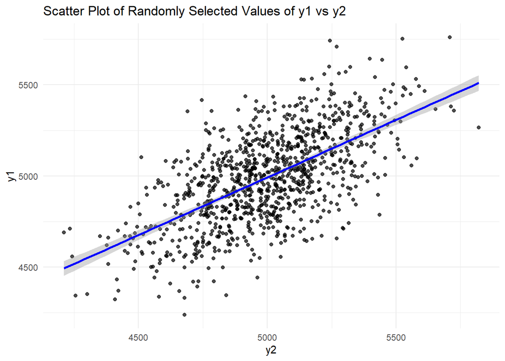

```r
library(ggplot2)

ggplot(sampled_data, aes(x = y2, y = y1)) +
  geom_point(alpha = 0.7) +  # Scatter plot points
  labs(
    title = "Scatter Plot of Randomly Selected Values of y1 vs y2",
    x = "y2",
    y = "y1"
  ) +
  theme_minimal() +
  geom_smooth(method = "lm", color = "blue", se = TRUE)  # Add regression line
```

```r
sampled_data <- simulated_data %>%
  group_by(id) %>%
  sample_n(1) %>%  # Randomly sample one row per individual
  ungroup()

model <- lm(y1 ~ y2, data = sampled_data)

summary(model)
```

```
##
## Call:
## lm(formula = y1 ~ y2, data = sampled_data)
##
## Residuals:
##     Min      1Q  Median      3Q     Max
## -518.43 -137.95   -1.24  137.92  595.41
##
## Coefficients:
##              Estimate Std. Error t value Pr(>|t|)
## (Intercept) 1.767e+03  1.257e+02   14.07   <2e-16 ***
## y2          6.450e-01  2.512e-02   25.68   <2e-16 ***
## ---
## Signif. codes:  0 '***' 0.001 '**' 0.01 '*' 0.05 '.' 0.1 ' ' 1
##
## Residual standard error: 194.8 on 998 degrees of freedom
## Multiple R-squared:  0.3978, Adjusted R-squared:  0.3972
## F-statistic: 659.4 on 1 and 998 DF,  p-value: < 2.2e-16
```

```r
r_squared <- summary(model)$r.squared

cat("% de y1 explicada por y2 (R^2):", r_squared, "\n")
```

```
## % de y1 explicada por y2 (R^2): 0.3978487
```

# Inter-intra raters

Este código tiene como objetivo calcular la **Correlación Intraclase (ICC)** para las variables `y1`, `y2` y `y3` en un conjunto de datos de panel, donde los individuos se miden en múltiples puntos de tiempo. Se utilizan los paquetes `tidyr` para reorganizar los datos y `psych` para calcular el ICC.

### Descripción del código:

1. **Reorganización de los datos en formato ancho**: Para calcular el ICC, los datos se transforman en formato ancho, de tal manera que cada fila representa a un individuo (`id`) y las columnas contienen las mediciones para cada variable (`y1`, `y2`, `y3`) en diferentes momentos de tiempo (`time`).
   - `pivot_wider` reorganiza los datos para que cada variable (`y1`, `y2`, `y3`) tenga una columna por cada punto de tiempo, etiquetadas como `time_1`, `time_2`, etc.

```r
library(psych)

y1_wide <- simulated_data %>%
  select(id, time, y1) %>%
  pivot_wider(names_from = time, values_from = y1, names_prefix = "time_")

y2_wide <- simulated_data %>%
  select(id, time, y2) %>%
  pivot_wider(names_from = time, values_from = y2, names_prefix = "time_")

y3_wide <- simulated_data %>%
  select(id, time, y3) %>%
  pivot_wider(names_from = time, values_from = y3, names_prefix = "time_")

icc_y1 <- ICC(y1_wide[ , -1])  # Quitamos ids
icc_y2 <- ICC(y2_wide[ , -1])
icc_y3 <- ICC(y3_wide[ , -1])
```